# Simulations

```r
library(mimiSBM)
```

# Data generation

## First simulation: no label-switching

### Setup of parameters

First of all, we’ll start by specifying our parameters for simulating the data: `N` Number of observations `V` Number of views `K` Vector of size Q, indicate the number of clusters in each component. `pi_k` Vector of proportions of observations across the real clusters. `rho` Vector of proportion of views across components. `sorted` Boolean for simulation reordering (clusters and components membership). `p_switch` probability of label-switching, if NULL no perturbation between true clustering and the connectivity of individuals.

```r
set.seed(42)
N <- 100
V <- 10
K <- c(2,3,4)
pi_k <- rep(1/5,5) # Here the true number of clusters will be equal to 5
rho <- rep(1/length(K),length(K))
sorted = TRUE
p_switch = NULL
```

### Simulation

```r
res <- rSMB_partition(N = N,V = V,K = K,pi_k = pi_k,rho = rho,sorted = sorted,p_switch = p_switch)
```

With the `plot_adjacency`function, adjacency matrices can be shown, and and linked to the parameters used for simulation.

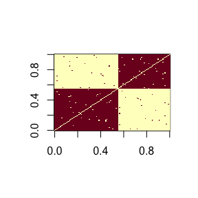

```r
#plot_adjacency(res$simulation$A)
image(res$simulation$A[,,1])
```

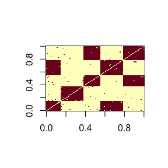

```r
image(res$simulation$A[,,3])
```

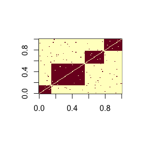

```r
image(res$simulation$A[,,10])
```

In this simulation, we have 3 types of adjacency matrices, depending precisely on the mixture from which they are derived. From the `clusters` variable in the simulation we can see the link between true clustering and that partially accessible through simulated views.

```r
(clust <- res$params$clusters)
```

```
#> [[1]]
#> [[1]][[1]]
#> [1] 1 2 3
#>
#> [[1]][[2]]
#> [1] 5 4
#>
#>
#> [[2]]
#> [[2]][[1]]
#> [1] 4 1
#>
#> [[2]][[2]]
#> [1] 2
#>
#> [[2]][[3]]
#> [1] 5 3
#>
#>
#> [[3]]
#> [[3]][[1]]
#> [1] 4
#>
#> [[3]][[2]]
#> [1] 1
#>
#> [[3]][[3]]
#> [1] 5
#>
#> [[3]][[4]]
#> [1] 2 3
```

This variable is difficult to understand at first glance, so we’ll explain its interpretation below.

```r
length(clust)
```

```
#> [1] 3
```

This variable is a list with as many arguments as the number of components.

Let’s take the example of the 1st element in the list:

```r
clust[[1]]
```

```
#> [[1]]
#> [1] 1 2 3
#>
#> [[2]]
#> [1] 5 4
```

The adjacency matrices resulting from the 1st component will therefore have 2 clusters. In addition, based on true clustering, we associate the cluster observed in this component: - Clusters 1, 2 and 3 are in fact a single cluster, cluster 1, of this component. - Cluster 4 and 5 correspond to the cluster 2 for this component.

If we look at the connection tensor linked to this simulation, we find the main structures observed previously.

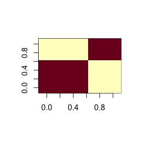

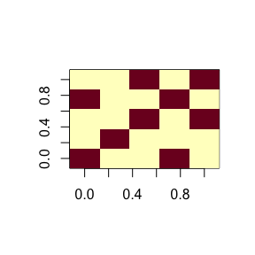

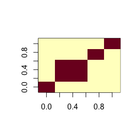

```r
sapply(1:3,function(s){image(res$params$alpha_klq[,,s])})
```

## Second simulation: label-switching

### Setup of parameters

This time we’ll set the label-switching to $10\%$, the probability that an individual will be associated with the wrong cluster when the adjacency matrix is created.

```r
set.seed(42)
N <- 100
V <- 10
K <- c(2,3,4)
pi_k <- rep(1/5,5) # Here the true number of clusters will be equal to 5
rho <- rep(1/length(K),length(K))
sorted = TRUE
p_switch = 0.1
```

### Simulation

```r
res <- rSMB_partition(N = N,V = V,K = K,pi_k = pi_k,rho = rho,sorted = sorted,p_switch = p_switch)
```

With the `plot_adjacency`function, adjacency matrices can be shown, and and linked to the parameters used for simulation.

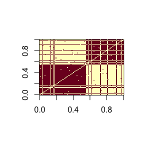

```r
#plot_adjacency(res$simulation$A)
image(res$simulation$A[,,1])
```

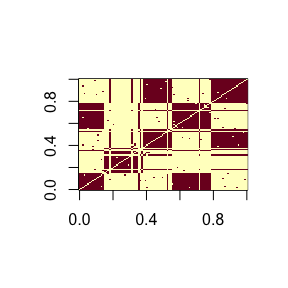

```r
image(res$simulation$A[,,3])
```

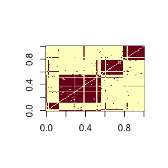

```r
image(res$simulation$A[,,10])
```

Compared with the previous simulation, there’s a clear disturbance in the adjacency matrices. However, the main structures are preserved.

What’s more, here we can still recognize these structures because the observations have been ordered according to their clusters. If we replace the parameter with `FALSE`, we’ll not be able to recognize structures easily.

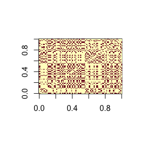

```r
res <- rSMB_partition(N = N,V = V,K = K,pi_k = pi_k,rho = rho,sorted = FALSE,p_switch = p_switch)
#plot_adjacency(res$simulation$A)
image(res$simulation$A[,,1])
```

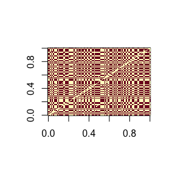

```r
image(res$simulation$A[,,3])
```

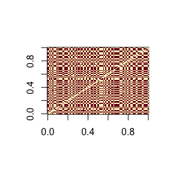

```r
image(res$simulation$A[,,10])
```